# Normal Distributions in R

Mike Hitchman

Math 140

# The Standard normal distribution $N(0,1)$

Suppose $Z$ is standard normal. That is, $Z$ is a normal distribution with mean 0 and standard deviation 1, and $Z$ has density curve looking like this:

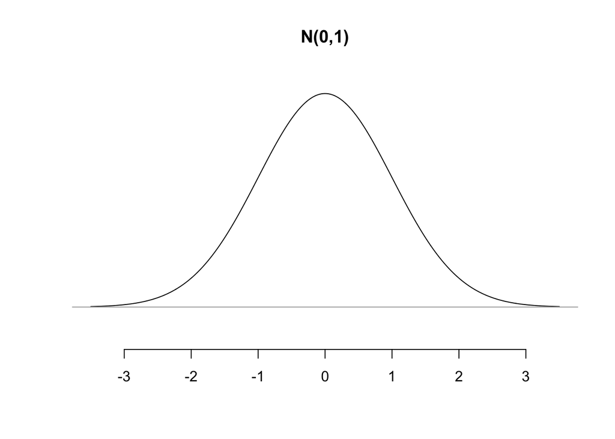

R has nice built-in functions to answer two questions:

1. What is $P(Z \leq z)$? In other words, what is the area under the density curve to the left of $Z = z$? This is a question of *cumulative probability*.
2. What is the value of $Z$ below which one finds a particular proportion of the density curve? This is a question of *finding a quantile*.

# Cumulative probabilities with `pnorm()`

> Use the `pnorm()` function!

> The `pnorm(z)` function gives the area to the left of $z$ under the $N(0,1)$ density curve.

## Example: Determine $P(Z \leq 1.54)$.

Answer:

```r
pnorm(1.54)
```

```
## [1] 0.9382198
```

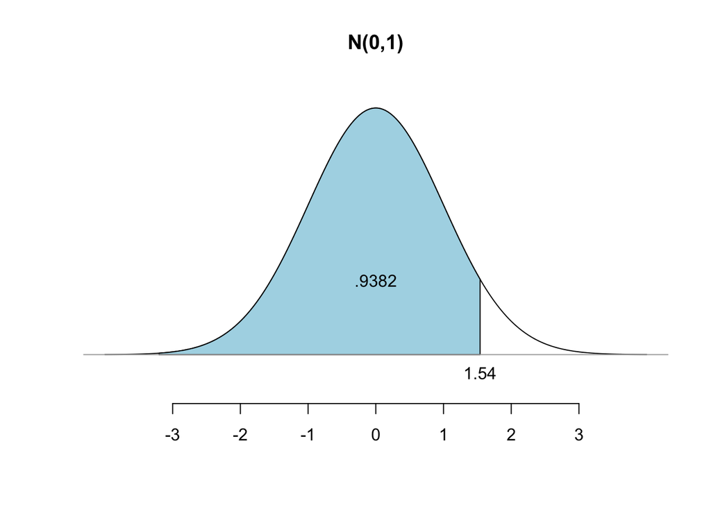

- `pnorm(1.54)` = 0.9382
- Interpretation: 93.82% of the distribution has a value less than $z = 1.54$.
- Note: The **area to the right** of 1.54 is `1-pnorm(1.54)` = 0.0618

## Example: Determine $P(Z > 0.6)$.

Answer:

```r
1-pnorm(0.6)
```

```
## [1] 0.2742531
```

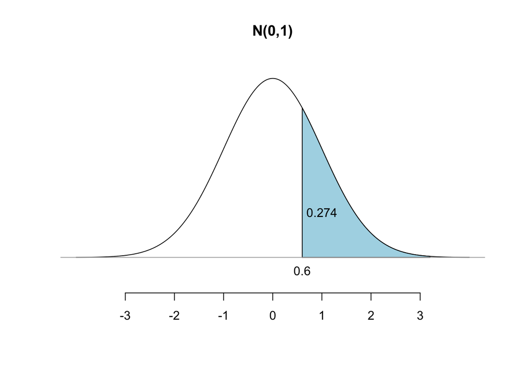

## Example: Find $P(-0.23 < Z < 1.54)$

Answer:

```r
pnorm(1.54)-pnorm(-0.23)
```

```
## [1] 0.5291739
```

- Why does `pnorm(1.54)-pnorm(-0.23)` do the trick?
- Subtracting two “areas to the left” leaves the area in between.
- So 52.92% of the dist’n is between -0.23 and 1.54.

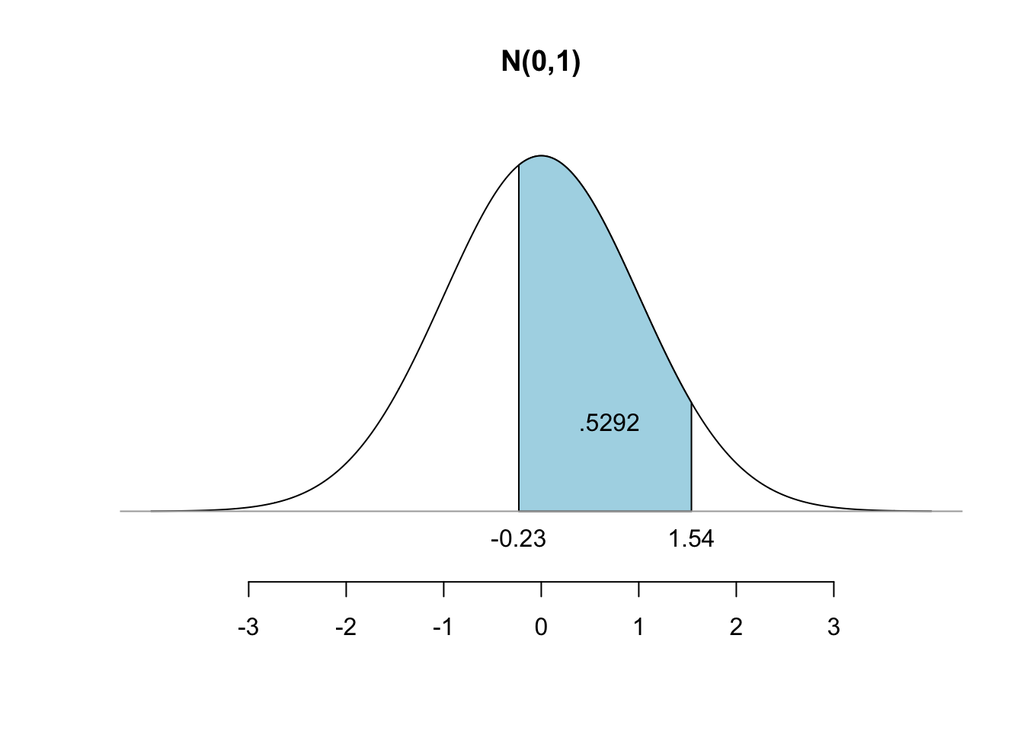

# Quantiles with `qnorm()`

> Use the `qnorm()` function!

> The `qnorm(a)` function gives the value $L$ such that $P(Z\leq L)=a.$

## Example: Find the 90th percentile.

> Determine the value $L$ in $N(0,1)$ that marks the 90th percentile. That is, find $L$ such that the area to the left of $L$ under the standard normal bell curve equals 0.9

Answer:

```r
qnorm(0.9)
```

```
## [1] 1.281552
```

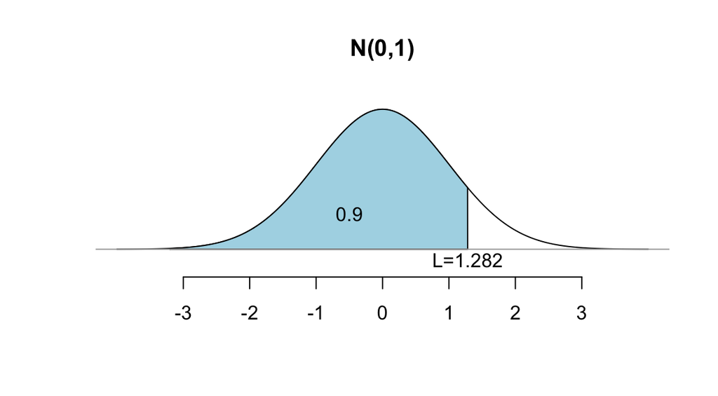

# Other Normal Distributions

> Fact: If $X$ is $N(\mu,\sigma)$ then
> $$Z = \frac{X-\mu}{\sigma} \text{ is }
> N(0,1).$$

## Example: Convert to Z-scores

> Suppose a distribution $X$ is $N(10,2)$, and determine $P(X < 9.1)$.

```r
pnorm(-0.45)
```

```
## [1] 0.3263552
```

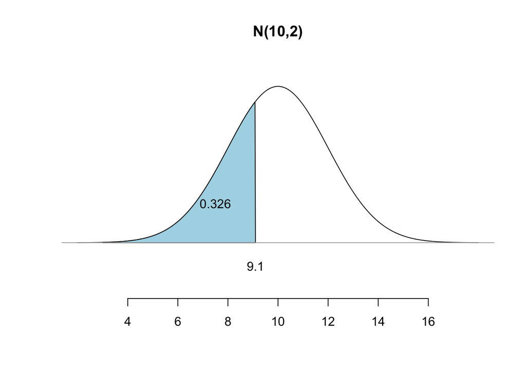

**Solution 2 in R**: Specify the mean $\mu$ and standard deviation $\sigma$ in the `pnorm()` command and use the original value of $X$ - we don’t convert to $Z$-scores:

```r
pnorm(9.1, mean=10, sd=2)
```

```
## [1] 0.3263552
```

## Example: Finding the top 1%

> What value of $X$ marks the top 1% of the $N(10,2)$ distribution?

**Solution 1**: First, find the $Z$-score in N(0,1) that marks the top 1% of that distribution. This is the value that has area 0.99 to the left of it:

```r
qnorm(.99)
```

```
## [1] 2.326348
```

Then, find the value $L$ in the given N(10,2) distribution that has this $Z$-score by solving this equation for $L$:

$$\begin{align*}
\frac{L-10}{2}&=2.326 \\
L-10 &= 2\cdot 2.326 \\
L-10 &= 4.652 \\
L &= 10 + 4.652 \\
L &= 14.652
\end{align*}$$

**Solution 2 in R**: We can specify the mean and standard deviation for any normal distribution within the `qnorm()` function, without first converting the question to one about $Z$-scores:

```r
qnorm(.99,mean=10,sd=2)
```

```
## [1] 14.6527
```

# Postscript

## Code for a standardized scores example

```
df <- read.csv("https://mphitchman.com/stats/data/normal_act_data.csv")
# get a sense of the shape of the length and width distributions
ggplot(df)+
  geom_histogram(aes(x=width),col="white",fill="chocolate",binwidth=.2,alpha=.4)+
  geom_histogram(aes(x=length),col="white",fill="purple",binwidth=.2,alpha=.4)+
  xlab("width (brown) and length (purple)")+
  ggtitle("Length and Width Distributions")

#create a standardized score column for the length:
df$Z_L = (df$length-mean(df$length))/sd(df$length)

#plot the lengths
ggplot(df)+geom_histogram(aes(x=Z_L),col="white",fill="purple",binwidth=.2,alpha=.4)+
  xlab("length standardized scores")+ggtitle("Distribution of length Z-scores")

#create a function for drawing a sample of size 50 from the population of all rectangles.
draw.sample<-function(df,n){
  chosen.rows<-sample(1:nrow(df),n)
  return(df[chosen.rows,])
}

#draw a sample of size 100!
df.sample<-draw.sample(df,100)

#What colors appeared?
table(df$color)

ggplot(df)+
  geom_histogram(aes(length),col="white",fill="purple",binwidth=.2,alpha=.4)
```